# Biostat 203B Homework 3

Due Feb 23 @ 11:59PM

Author

Hiroyasu Ando, UID: 605948443

Load necessary libraries (you can add more as needed).

```r
library(arrow)
library(memuse)
library(pryr)
library(R.utils)
library(tidyverse)
```

Display your machine memory.

```r
memuse::Sys.meminfo()
```

```
Totalram:   16.000 GiB
Freeram:   376.047 MiB
```

In this exercise, we use tidyverse (ggplot2, dplyr, etc) to explore the [MIMIC-IV](https://mimic.mit.edu/docs/iv/) data introduced in [homework 1](https://ucla-biostat-203b.github.io/2024winter/hw/hw1/hw1.html) and to build a cohort of ICU stays.

## Q1. Visualizing patient trajectory

Visualizing a patient’s encounters in a health care system is a common task in clinical data analysis. In this question, we will visualize a patient’s ADT (admission-discharge-transfer) history and ICU vitals in the MIMIC-IV data.

### Q1.1 ADT history

A patient’s ADT history records the time of admission, discharge, and transfer in the hospital. This figure shows the ADT history of the patient with `subject_id` 10001217 in the MIMIC-IV data. The x-axis is the calendar time, and the y-axis is the type of event (ADT, lab, procedure). The color of the line segment represents the care unit. The size of the line segment represents whether the care unit is an ICU/CCU. The crosses represent lab events, and the shape of the dots represents the type of procedure. The title of the figure shows the patient’s demographic information and the subtitle shows top 3 diagnoses.

[figure not shown]

Do a similar visualization for the patient with `subject_id` 10013310 using ggplot.

Hint: We need to pull information from data files `patients.csv.gz`, `admissions.csv.gz`, `transfers.csv.gz`, `labevents.csv.gz`, `procedures_icd.csv.gz`, `diagnoses_icd.csv.gz`, `d_icd_procedures.csv.gz`, and `d_icd_diagnoses.csv.gz`. For the big file `labevents.csv.gz`, use the Parquet format you generated in Homework 2. For reproducibility, make the Parquet folder `labevents_pq` available at the current working directory `hw3`, for example, by a symbolic link. Make your code reproducible.

**Answer**

Put “labevents.parquet” in the current working directory, `hw3`, as “labevents_pq”.

```bash
ln -s ../hw2/labevents.parquet ./labevents_pq
```

Specify the `subject_id`.

```r
patient_id = 10013310
```

Retrieve the patient’s gender and age.

```r
patients <- read_csv("~/mimic/hosp/patients.csv.gz") |>
  filter(subject_id %in% patient_id)

patient_gender = patients$gender[1]
patient_age = patients$anchor_age[1]
```

Extract the patient race.

```r
patient_race <- read_csv("~/mimic/hosp/admissions.csv.gz") |>
  filter(subject_id %in% patient_id) |>
  select(race) |>
  distinct() |>
  pull() |>
  tolower()
```

Retrieve the patient’s top 3 diagnoses. I used ‘hadn_id’, 21243435.

```r
patient_diagnoses <- read_csv("~/mimic/hosp/diagnoses_icd.csv.gz") |>
  left_join(read_csv("~/mimic/hosp/d_icd_diagnoses.csv.gz"),
            by = c("icd_code", "icd_version")) |>
  filter(subject_id %in% patient_id) |>
  arrange(hadm_id, seq_num) |>
  select(long_title) |>
  slice_head(n = 3)

diagnose_1 <- tolower(patient_diagnoses$long_title[1])
diagnose_2 <- tolower(patient_diagnoses$long_title[2])
diagnose_3 <- tolower(patient_diagnoses$long_title[3])
```

Make the ADT history data.

```r
transfers <- read_csv("~/mimic/hosp/transfers.csv.gz") |>
  filter(subject_id %in% patient_id) |>
  select(careunit, intime, outtime) |>
  # Fix the timezone issue
  mutate(intime = with_tz(intime, "UTC"),
         outtime = with_tz(outtime, "UTC"))

# Get the number of the distinct careunit
careunit_num <- transfers |>
  select(careunit) |>
  distinct() |>
  nrow()

adt <- transfers |>
  mutate(y_type = "ADT",
         line_size = if_else(
           # Detect if the careunit is ICU or CCU
           str_detect(careunit, "CCU") | str_detect(careunit, "ICU"),
           8, 3)) |>
  # Fix the length of careunit less than 35
  mutate(careunit = str_sub(careunit, 1, 35)) |>
  na.omit() |>
  arrange(intime)
```

Make the lab events data.

```r
labevents = open_dataset(sources = "./labevents_pq", format = "parquet") |>
  filter(subject_id %in% patient_id) |>
  select(charttime) |>
  as_tibble() |>
  mutate(y_type = "Lab") |>
  # Fix the timezone issue
  mutate(charttime = with_tz(charttime, "UTC")) |>
  arrange(charttime)
```

Make the procedures data.

```r
procedures <- read_csv("~/mimic/hosp/procedures_icd.csv.gz") |>
  filter(subject_id %in% patient_id) |>
  left_join(read_csv("~/mimic/hosp/d_icd_procedures.csv.gz"),
            by = c("icd_code", "icd_version")) |>
  mutate(y_type = "Procedure",
         # Fix the timezone issue
         chartdate = with_tz(chartdate, "UTC")) |>
  # Fix the date format
  mutate(chartdate = as.POSIXct(chartdate, format = "%Y-%m-%d %H:%M:%S")) |>
  # Fix the length of long_title less than 25
  mutate(long_title = str_sub(long_title, 1, 25))

# Get the number of the distinctive procedures
long_title_num <- procedures |>
  select(long_title) |>
  distinct() |>
  nrow()
```

Make the plot.

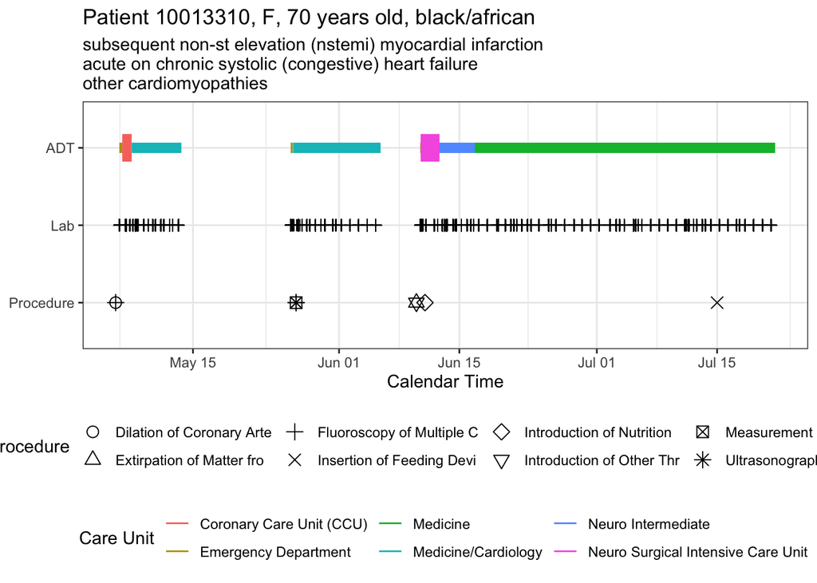

```r
ggplot() +
  geom_point(data = labevents, aes(x = charttime, y = y_type),
             shape = 3, color = "black", size = 2) +
  geom_segment(data = adt,
               aes(x = intime, xend = outtime, y = y_type, yend = y_type,
                   color = careunit), linewidth = adt$line_size) +
  geom_point(data = procedures, aes(x = chartdate,
                                    y = y_type,
                                    shape = long_title), size = 3) +
  scale_shape_manual(values = seq(1, long_title_num)) +
  theme_bw() +
  theme(legend.position = "bottom", legend.box = "vertical",
        axis.title.y = element_blank()) +
  guides(linewidth = "none",
         color = guide_legend(order = 2, title = "Care Unit"),
         shape = guide_legend(order = 1, title = "Procedure"))+
  labs(title = paste0("Patient ",
                      patient_id, ", ",
                      patient_gender, ", ",
                      patient_age, " ",
                      "years old, ", patient_race),
       x = "Calendar Time",
       subtitle = paste0(diagnose_1, "\n", diagnose_2, "\n", diagnose_3)) +
  scale_y_discrete(limits = c("Procedure", "Lab", "ADT"))
```

### Q1.2 ICU stays

ICU stays are a subset of ADT history. This figure shows the vitals of the patient `10001217` during ICU stays. The x-axis is the calendar time, and the y-axis is the value of the vital. The color of the line represents the type of vital. The facet grid shows the abbreviation of the vital and the stay ID.

[figure not shown]

**Answer**

Put “chartevents.parquet” in the current working directory, `hw3`, as “chartevents_pq”.

```bash
ln -s ../hw2/chartevents.parquet ./chartevents_pq
```

Specify the `subject_id`.

```r
patient_id = 10013310
```

Retrieve the ICU stays of the patient.

```r
icustays <- read_csv("~/mimic/icu/icustays.csv.gz") |>
  filter(subject_id %in% patient_id) |>
  select(hadm_id, stay_id) |>
  distinct()
```

Find the itemid of the vitals.

```r
transfers <- read_csv("~/mimic/icu/d_items.csv.gz") |>
  filter(abbreviation == "NBPd" | abbreviation == "NBPs" |
           abbreviation == "HR" | abbreviation == "Temperature F" |
           abbreviation == "RR") |>
  select(itemid, abbreviation) |>
  print(width = Inf)
```

```
# A tibble: 5 × 2
  itemid abbreviation
   <dbl> <chr>
1 220045 HR
2 220179 NBPs
3 220180 NBPd
4 220210 RR
5 223761 Temperature F
```

Make the labevents data with all necessary information.

```r
labevents = open_dataset(sources = "./chartevents_pq",
                         format = "parquet") |>
  select(subject_id, itemid, charttime, value, storetime, hadm_id, valuenum) |>
  filter(subject_id %in% patient_id) |>
  filter(itemid %in% c(220045, 220179, 220180, 223761, 220210)) |>
  collect() |>
  left_join(icustays, by = c("hadm_id" = "hadm_id")) |>
  left_join(transfers, by = c("itemid" = "itemid")) |>
  # Fix the timezone issue
  mutate(charttime = with_tz(charttime, "UTC")) |>
  arrange(stay_id, charttime)
```

Make the plot.

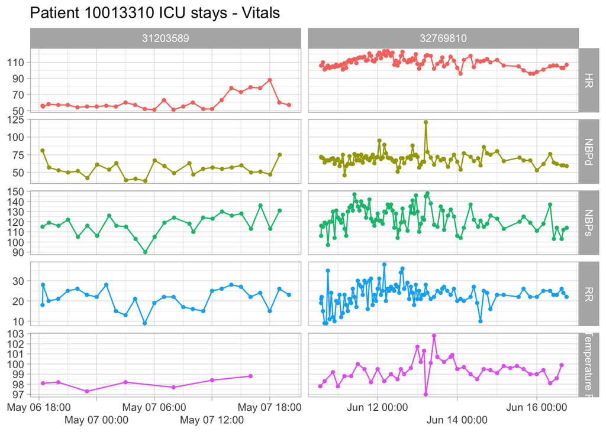

```r
ggplot() +
  geom_line(data = labevents, mapping = aes(x = charttime, y = valuenum,
                                            color = as.factor(abbreviation))) +
  geom_point(data = labevents, mapping = aes(x = charttime,
                                             y = valuenum,
                                             color = as.factor(abbreviation)),
             size = 1) +
  facet_grid(abbreviation ~ stay_id, scales = "free") +
  theme_light() +
  guides(color = "none",
         x = guide_axis(n.dodge = 2)) +
  theme(axis.title.y = element_blank(), axis.title.x = element_blank()) +
  scale_x_datetime(labels = scales::date_format("%b %d %H:%M")) +
  labs(title = paste0("Patient ", patient_id, " ICU stays - Vitals"))
```

## Q2. ICU stays

`icustays.csv.gz` (https://mimic.mit.edu/docs/iv/modules/icu/icustays/) contains data about Intensive Care Units (ICU) stays. The first 10 lines are

```bash
zcat < ~/mimic/icu/icustays.csv.gz | head
```

```
subject_id,hadm_id,stay_id,first_careunit,last_careunit,intime,outtime,los
10000032,29079034,39553978,Medical Intensive Care Unit (MICU),Medical Intensive Care Unit (MICU),2180-07-23 14:00:00,2180-07-23 23:50:47,0.4102662037037037
10000980,26913865,39765666,Medical Intensive Care Unit (MICU),Medical Intensive Care Unit (MICU),2189-06-27 08:42:00,2189-06-27 20:38:27,0.4975347222222222
10001217,24597018,37067082,Surgical Intensive Care Unit (SICU),Surgical Intensive Care Unit (SICU),2157-11-20 19:18:02,2157-11-21 22:08:00,1.1180324074074075
10001217,27703517,34592300,Surgical Intensive Care Unit (SICU),Surgical Intensive Care Unit (SICU),2157-12-19 15:42:24,2157-12-20 14:27:41,0.9481134259259258
10001725,25563031,31205490,Medical/Surgical Intensive Care Unit (MICU/SICU),Medical/Surgical Intensive Care Unit (MICU/SICU),2110-04-11 15:52:22,2110-04-12 23:59:56,1.338587962962963
10001884,26184834,37510196,Medical Intensive Care Unit (MICU),Medical Intensive Care Unit (MICU),2131-01-11 04:20:05,2131-01-20 08:27:30,9.171817129629629
10002013,23581541,39060235,Cardiac Vascular Intensive Care Unit (CVICU),Cardiac Vascular Intensive Care Unit (CVICU),2160-05-18 10:00:53,2160-05-19 17:33:33,1.3143518518518518
10002155,20345487,32358465,Medical Intensive Care Unit (MICU),Medical Intensive Care Unit (MICU),2131-03-09 21:33:00,2131-03-10 18:09:21,0.8585763888888889
10002155,23822395,33685454,Coronary Care Unit (CCU),Coronary Care Unit (CCU),2129-08-04 12:45:00,2129-08-10 17:02:38,6.178912037037037
```

### Q2.1 Ingestion

**Answer**

Import `icustays.csv.gz` as a tibble `icustays_tble`.

```r
icustays_tble <- read_csv("~/mimic/icu/icustays.csv.gz") |>
  as_tibble()
```

### Q2.2 Summary and visualization

How many unique `subject_id`? Can a `subject_id` have multiple ICU stays? Summarize the number of ICU stays per `subject_id` by graphs.

**How many unique `subject_id`?**

There are 50920 unique `subject_id`.

```r
icustays_tble |>
  distinct(subject_id) |>
  nrow()
```

```
[1] 50920
```

**Can a `subject_id` have multiple ICU stays?**

The numbers of unique `subject_id` and `stay_id` are different, which means a `subject_id` can have multiple ICU stays.

```r
icustays_tble |>
  distinct(stay_id) |>
  nrow()
```

```
[1] 73181
```

**Summarize the number of ICU stays per `subject_id` by graphs.**

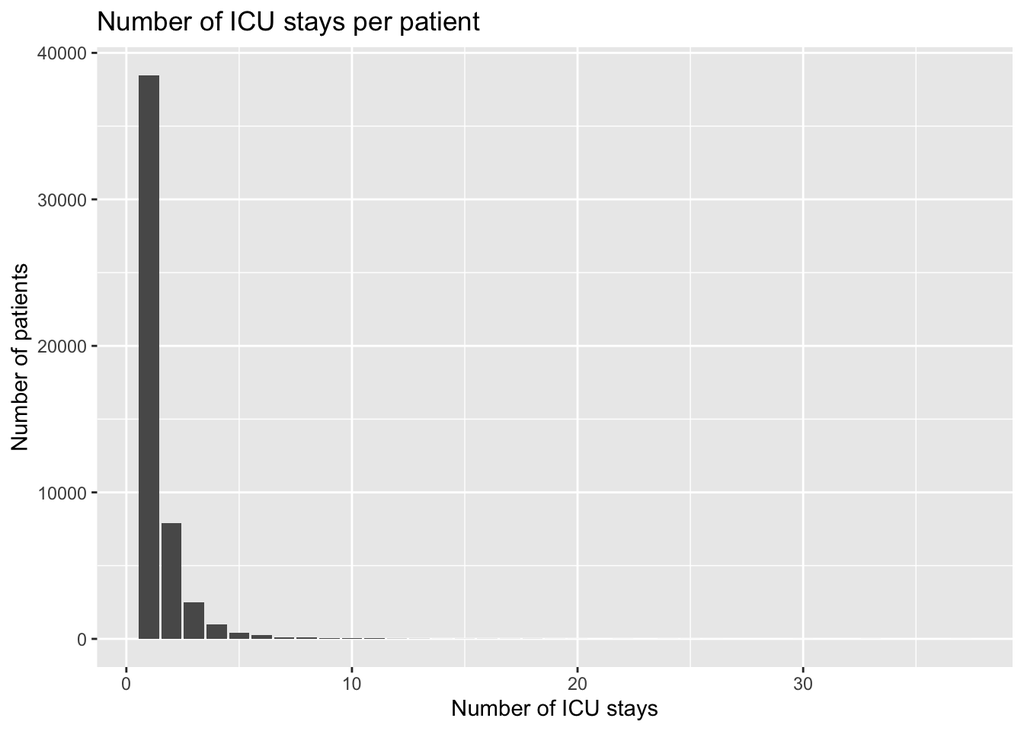

```r
icustays_tble |>
  group_by(subject_id) |>
  summarize(n = n()) |>
  ggplot(aes(x = n)) +
  geom_bar() +
  labs(title = "Number of ICU stays per patient",
       x = "Number of ICU stays",
       y = "Number of patients")
```

## Q3. `admissions` data

Information of the patients admitted into hospital is available in `admissions.csv.gz`. See https://mimic.mit.edu/docs/iv/modules/hosp/admissions/ for details of each field in this file. The first 10 lines are

```bash
zcat < ~/mimic/hosp/admissions.csv.gz | head
```

```
subject_id,hadm_id,admittime,dischtime,deathtime,admission_type,admit_provider_id,admission_location,discharge_location,insurance,language,marital_status,race,edregtime,edouttime,hospital_expire_flag
10000032,22595853,2180-05-06 22:23:00,2180-05-07 17:15:00,,URGENT,P874LG,TRANSFER FROM HOSPITAL,HOME,Other,ENGLISH,WIDOWED,WHITE,2180-05-06 19:17:00,2180-05-06 23:30:00,0
10000032,22841357,2180-06-26 18:27:00,2180-06-27 18:49:00,,EW EMER.,P09Q6Y,EMERGENCY ROOM,HOME,Medicaid,ENGLISH,WIDOWED,WHITE,2180-06-26 15:54:00,2180-06-26 21:31:00,0
10000032,25742920,2180-08-05 23:44:00,2180-08-07 17:50:00,,EW EMER.,P60CC5,EMERGENCY ROOM,HOSPICE,Medicaid,ENGLISH,WIDOWED,WHITE,2180-08-05 20:58:00,2180-08-06 01:44:00,0
10000032,29079034,2180-07-23 12:35:00,2180-07-25 17:55:00,,EW EMER.,P30KEH,EMERGENCY ROOM,HOME,Medicaid,ENGLISH,WIDOWED,WHITE,2180-07-23 05:54:00,2180-07-23 14:00:00,0
10000068,25022803,2160-03-03 23:16:00,2160-03-04 06:26:00,,EU OBSERVATION,P51VDL,EMERGENCY ROOM,,Other,ENGLISH,SINGLE,WHITE,2160-03-03 21:55:00,2160-03-04 06:26:00,0
10000084,23052089,2160-11-21 01:56:00,2160-11-25 14:52:00,,EW EMER.,P6957U,WALK-IN/SELF REFERRAL,HOME HEALTH CARE,Medicare,ENGLISH,MARRIED,WHITE,2160-11-20 20:36:00,2160-11-21 03:20:00,0
10000084,29888819,2160-12-28 05:11:00,2160-12-28 16:07:00,,EU OBSERVATION,P63AD6,PHYSICIAN REFERRAL,,Medicare,ENGLISH,MARRIED,WHITE,2160-12-27 18:32:00,2160-12-28 16:07:00,0
10000108,27250926,2163-09-27 23:17:00,2163-09-28 09:04:00,,EU OBSERVATION,P38XXV,EMERGENCY ROOM,,Other,ENGLISH,SINGLE,WHITE,2163-09-27 16:18:00,2163-09-28 09:04:00,0
10000117,22927623,2181-11-15 02:05:00,2181-11-15 14:52:00,,EU OBSERVATION,P2358X,EMERGENCY ROOM,,Other,ENGLISH,DIVORCED,WHITE,2181-11-14 21:51:00,2181-11-15 09:57:00,0
```

### Q3.1 Ingestion

Import `admissions.csv.gz` as a tibble `admissions_tble`.

```r
admissions_tble <- read_csv("~/mimic/hosp/admissions.csv.gz") |>
  as_tibble()
```

### Q3.2 Summary and visualization

Summarize the following information by graphics and explain any patterns you see.

- number of admissions per patient
- admission hour (anything unusual?)
- admission minute (anything unusual?)
- length of hospital stay (from admission to discharge) (anything unusual?)

**Number of admissions per patient**

As the number of admissions per patient increases, the number of patients decreases.

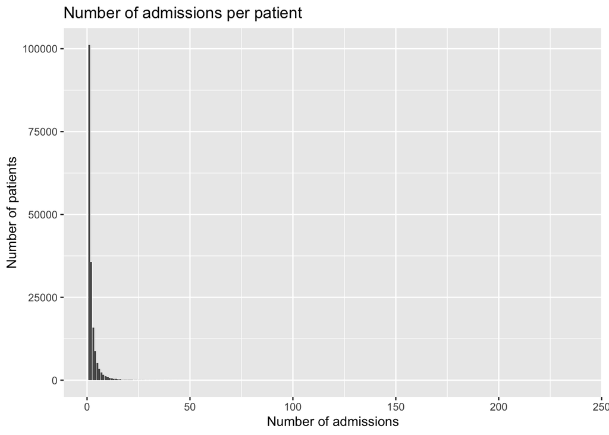

```r
admissions_tble |>
  group_by(subject_id) |>
  summarize(n = n()) |>
  ggplot(aes(x = n)) +
  geom_bar() +
  labs(title = "Number of admissions per patient",
       x = "Number of admissions",
       y = "Number of patients")
```

**Admission hour (anything unusual?)**

```r
admissions_tble <- read_csv("~/mimic/hosp/admissions.csv.gz") |>
  as_tibble() |>
  mutate(admittime = with_tz(admittime, "UTC")) |>
  mutate(admithour = format(admittime, "%H"))
```

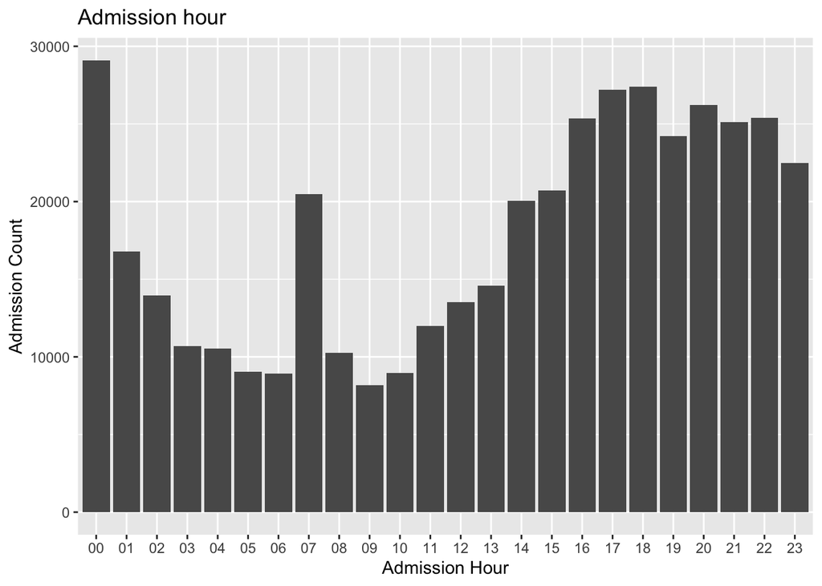

```r
admissions_tble |>
  ggplot(aes(x = admithour)) +
  geom_bar() +
  labs(title = "Admission hour",
       x = "Admission Hour",
       y = "Admission Count")
```

**Admission minute (anything unusual?)**

There is a peak at 00 minute, and then peak happens every 15 minutes. These peaks are getting smaller as the minute increases.

```r
admissions_tble <- read_csv("~/mimic/hosp/admissions.csv.gz") |>
  as_tibble() |>
  mutate(admitminute = format(admittime, "%M"))
```

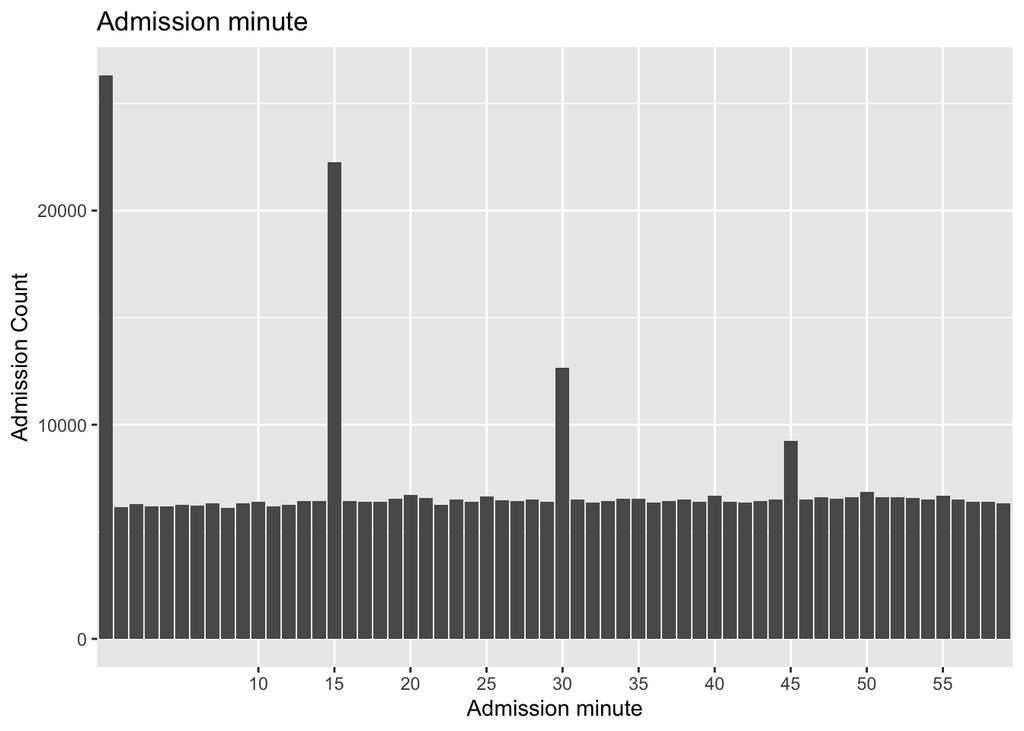

```r
admissions_tble |>
  ggplot(aes(x = admitminute)) +
  geom_bar() +
  labs(title = "Admission minute",
       x = "Admission minute",
       y = "Admission Count") +
  scale_x_discrete(breaks=seq(0, 60, by=5))
```

**length of hospital stay (from admission to discharge) (anything unusual?)**

As the length of hospital stay increases, the number of patients decreases. The most common length of hospital stay is a few days.

```r
admissions_tble <- admissions_tble |>
  mutate(hos_stay = as.numeric(difftime(dischtime, admittime, units = "days")))
```

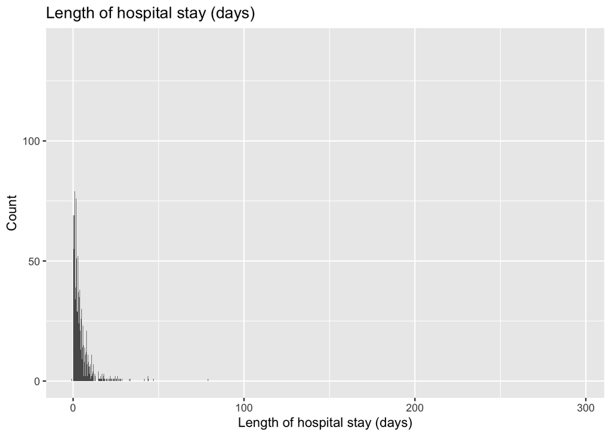

```r
admissions_tble |>
  ggplot(aes(x = hos_stay)) +
  geom_bar() +
  labs(title = "Length of hospital stay (days)",
       x = "Length of hospital stay (days)",
       y = "Count")
```

According to the [MIMIC-IV documentation](https://mimic.mit.edu/docs/iv/about/concepts/#date-shifting),

> All dates in the database have been shifted to protect patient confidentiality. Dates will be internally consistent for the same patient, but randomly distributed in the future. Dates of birth which occur in the present time are not true dates of birth. Furthermore, dates of birth which occur before the year 1900 occur if the patient is older than 89. In these cases, the patient’s age at their first admission has been fixed to 300.

## Q4. `patients` data

Patient information is available in `patients.csv.gz`. See https://mimic.mit.edu/docs/iv/modules/hosp/patients/ for details of each field in this file. The first 10 lines are

```bash
zcat < ~/mimic/hosp/patients.csv.gz | head
```

```
subject_id,gender,anchor_age,anchor_year,anchor_year_group,dod
10000032,F,52,2180,2014 - 2016,2180-09-09
10000048,F,23,2126,2008 - 2010,
10000068,F,19,2160,2008 - 2010,
10000084,M,72,2160,2017 - 2019,2161-02-13
10000102,F,27,2136,2008 - 2010,
10000108,M,25,2163,2014 - 2016,
10000115,M,24,2154,2017 - 2019,
10000117,F,48,2174,2008 - 2010,
10000178,F,59,2157,2017 - 2019,
```

### Q4.1 Ingestion

Import `patients.csv.gz` (https://mimic.mit.edu/docs/iv/modules/hosp/patients/) as a tibble `patients_tble`.

**Answer**

```r
patients_tble <- read_csv("~/mimic/hosp/patients.csv.gz") |>
  as_tibble()
```

### Q4.2 Summary and visualization

Summarize variables `gender` and `anchor_age` by graphics, and explain any patterns you see.

**Answer**

Men and women have the similar patterns. The number of patients in their early 20s, both male and female, is high. Also, the number of female patients is higher than the number of male patients.

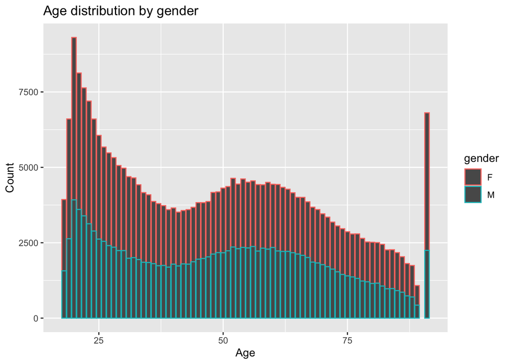

```r
patients_tble |>
  ggplot(aes(x = anchor_age, color = gender)) +
  geom_bar() +
  labs(title = "Age distribution by gender",
       x = "Age",
       y = "Count")
```

## Q5. Lab results

`labevents.csv.gz` (https://mimic.mit.edu/docs/iv/modules/hosp/labevents/) contains all laboratory measurements for patients. The first 10 lines are

```bash
zcat < ~/mimic/hosp/labevents.csv.gz | head
```

```
labevent_id,subject_id,hadm_id,specimen_id,itemid,order_provider_id,charttime,storetime,value,valuenum,valueuom,ref_range_lower,ref_range_upper,flag,priority,comments
1,10000032,,45421181,51237,P28Z0X,2180-03-23 11:51:00,2180-03-23 15:15:00,1.4,1.4,,0.9,1.1,abnormal,ROUTINE,
2,10000032,,45421181,51274,P28Z0X,2180-03-23 11:51:00,2180-03-23 15:15:00,___,15.1,sec,9.4,12.5,abnormal,ROUTINE,VERIFIED.
3,10000032,,52958335,50853,P28Z0X,2180-03-23 11:51:00,2180-03-25 11:06:00,___,15,ng/mL,30,60,abnormal,ROUTINE,NEW ASSAY IN USE ___: DETECTS D2 AND D3 25-OH ACCURATELY.
4,10000032,,52958335,50861,P28Z0X,2180-03-23 11:51:00,2180-03-23 16:40:00,102,102,IU/L,0,40,abnormal,ROUTINE,
5,10000032,,52958335,50862,P28Z0X,2180-03-23 11:51:00,2180-03-23 16:40:00,3.3,3.3,g/dL,3.5,5.2,abnormal,ROUTINE,
6,10000032,,52958335,50863,P28Z0X,2180-03-23 11:51:00,2180-03-23 16:40:00,109,109,IU/L,35,105,abnormal,ROUTINE,
7,10000032,,52958335,50864,P28Z0X,2180-03-23 11:51:00,2180-03-23 16:40:00,___,8,ng/mL,0,8.7,,ROUTINE,MEASURED BY ___.
8,10000032,,52958335,50868,P28Z0X,2180-03-23 11:51:00,2180-03-23 16:40:00,12,12,mEq/L,8,20,,ROUTINE,
9,10000032,,52958335,50878,P28Z0X,2180-03-23 11:51:00,2180-03-23 16:40:00,143,143,IU/L,0,40,abnormal,ROUTINE,
```

`d_labitems.csv.gz` (https://mimic.mit.edu/docs/iv/modules/hosp/d_labitems/) is the dictionary of lab measurements.

```bash
zcat < ~/mimic/hosp/d_labitems.csv.gz | head
```

```
itemid,label,fluid,category
50801,Alveolar-arterial Gradient,Blood,Blood Gas
50802,Base Excess,Blood,Blood Gas
50803,"Calculated Bicarbonate, Whole Blood",Blood,Blood Gas
50804,Calculated Total CO2,Blood,Blood Gas
50805,Carboxyhemoglobin,Blood,Blood Gas
50806,"Chloride, Whole Blood",Blood,Blood Gas
50808,Free Calcium,Blood,Blood Gas
50809,Glucose,Blood,Blood Gas
50810,"Hematocrit, Calculated",Blood,Blood Gas
```

We are interested in the lab measurements of creatinine (50912), potassium (50971), sodium (50983), chloride (50902), bicarbonate (50882), hematocrit (51221), white blood cell count (51301), and glucose (50931). Retrieve a subset of `labevents.csv.gz` that only containing these items for the patients in `icustays_tble`. Further restrict to the last available measurement (by `storetime`) before the ICU stay. The final `labevents_tble` should have one row per ICU stay and columns for each lab measurement.

[figure not shown]

Hint: Use the Parquet format you generated in Homework 2. For reproducibility, make `labevents_pq` folder available at the current working directory `hw3`, for example, by a symbolic link.

**Retrieve a subset of `labevents.csv.gz`**

```r
# Get the list of the patients in icustays_tble
patients_id_list <- icustays_tble |>
  select(subject_id) |>
  distinct() |>
  pull()

# Get the list of the required items in d_labitems.csv.gz
items_id_list <- read_csv("~/mimic/hosp/d_labitems.csv.gz") |>
  filter(itemid %in% c(50912,
                       50971,
                       50983,
                       50902,
                       50882,
                       51221,
                       51301,
                       50931))
# Get a subset of `labevents.csv.gz`
labevents_sub <- open_dataset(sources = "./labevents_pq", format = "parquet") |>
  select(subject_id, itemid, charttime, valuenum, storetime) |>
  filter(itemid %in% items_id_list$itemid) |>
  filter(subject_id %in% patients_id_list) |>
  collect() |>
  distinct()

labevents_sub
```

```
# A tibble: 13,473,497 × 5
   subject_id itemid charttime           valuenum storetime
        <int>  <int> <dttm>                 <dbl> <dttm>
 1   10002428  51301 2156-04-19 20:30:00     13.2 2156-04-19 20:56:00
 2   10002428  50882 2156-04-19 20:30:00     26   2156-04-19 21:33:00
 3   10002428  50902 2156-04-19 20:30:00    111   2156-04-19 21:33:00
 4   10002428  50912 2156-04-19 20:30:00      0.5 2156-04-19 21:33:00
 5   10002428  50931 2156-04-19 20:30:00    163   2156-04-19 21:33:00
 6   10002428  50971 2156-04-19 20:30:00      4.4 2156-04-19 21:33:00
 7   10002428  50983 2156-04-19 20:30:00    143   2156-04-19 21:33:00
 8   10002428  50882 2156-04-20 05:00:00     26   2156-04-20 06:09:00
 9   10002428  50902 2156-04-20 05:00:00    110   2156-04-20 06:09:00
10   10002428  50912 2156-04-20 05:00:00      0.5 2156-04-20 06:09:00
# ℹ 13,473,487 more rows
```

**The final `labevents_tble`**

Restrict to the last available measurement (by `storetime`) before the ICU stay.

```r
labevents_sub2 = labevents_sub |>
  left_join(icustays_tble, by = "subject_id") |>
  select(subject_id, itemid, valuenum, storetime, stay_id, intime, charttime) |>
  filter(storetime < intime) |>
  group_by(subject_id, stay_id, itemid) |>
  # Get the latest storetime
  slice_max(order_by = storetime) |>
  # Get the latest charttime
  slice_max(order_by = charttime) |>
  # Get the maxmum value of valuenum
  slice_max(order_by = valuenum) |>
  select(subject_id, itemid, valuenum, stay_id)
```

Make the final data.

```r
labevents_tble = labevents_sub2 |>
  pivot_wider(names_from = itemid, values_from = valuenum) |>
  arrange(subject_id, stay_id) |>
  ungroup() |>
  rename(setNames(as.character(items_id_list$itemid),
                  tolower(items_id_list$label))) |>
  # Change the column name, "white blood cells" to "wbc" manually
  rename("wbc" = "white blood cells") |>
  print(width = Inf)
```

```
# A tibble: 68,467 × 10
   subject_id  stay_id bicarbonate chloride creatinine glucose potassium sodium
        <dbl>    <dbl>       <dbl>    <dbl>      <dbl>   <dbl>     <dbl>  <dbl>
 1   10000032 39553978          25       95        0.7     102       6.7    126
 2   10000980 39765666          21      109        2.3      89       3.9    144
 3   10001217 34592300          30      104        0.5      87       4.1    142
 4   10001217 37067082          22      108        0.6     112       4.2    142
 5   10001725 31205490          NA       98       NA        NA       4.1    139
 6   10001884 37510196          30       88        1.1     141       4.5    130
 7   10002013 39060235          24      102        0.9     288       3.5    137
 8   10002155 31090461          23       98        2.8     117       4.9    135
 9   10002155 32358465          26       85        1.4     133       5.7    120
10   10002155 33685454          24      105        1.1     138       4.6    139
   hematocrit   wbc
        <dbl> <dbl>
 1       41.1   6.9
 2       27.3   5.3
 3       37.4   5.4
 4       38.1  15.7
 5       NA    NA
 6       39.7  12.2
 7       34.9   7.2
 8       25.5  17.9
 9       22.4   9.8
10       39.7   7.9
# ℹ 68,457 more rows
```

## Q6. Vitals from charted events

`chartevents.csv.gz` (https://mimic.mit.edu/docs/iv/modules/icu/chartevents/) contains all the charted data available for a patient. During their ICU stay, the primary repository of a patient’s information is their electronic chart. The `itemid` variable indicates a single measurement type in the database. The `value` variable is the value measured for `itemid`. The first 10 lines of `chartevents.csv.gz` are

```bash
zcat < ~/mimic/icu/chartevents.csv.gz | head
```

```
subject_id,hadm_id,stay_id,caregiver_id,charttime,storetime,itemid,value,valuenum,valueuom,warning
10000032,29079034,39553978,47007,2180-07-23 21:01:00,2180-07-23 22:15:00,220179,82,82,mmHg,0
10000032,29079034,39553978,47007,2180-07-23 21:01:00,2180-07-23 22:15:00,220180,59,59,mmHg,0
10000032,29079034,39553978,47007,2180-07-23 21:01:00,2180-07-23 22:15:00,220181,63,63,mmHg,0
10000032,29079034,39553978,47007,2180-07-23 22:00:00,2180-07-23 22:15:00,220045,94,94,bpm,0
10000032,29079034,39553978,47007,2180-07-23 22:00:00,2180-07-23 22:15:00,220179,85,85,mmHg,0
10000032,29079034,39553978,47007,2180-07-23 22:00:00,2180-07-23 22:15:00,220180,55,55,mmHg,0
10000032,29079034,39553978,47007,2180-07-23 22:00:00,2180-07-23 22:15:00,220181,62,62,mmHg,0
10000032,29079034,39553978,47007,2180-07-23 22:00:00,2180-07-23 22:15:00,220210,20,20,insp/min,0
10000032,29079034,39553978,47007,2180-07-23 22:00:00,2180-07-23 22:15:00,220277,95,95,%,0
```

`d_items.csv.gz` (https://mimic.mit.edu/docs/iv/modules/icu/d_items/) is the dictionary for the `itemid` in `chartevents.csv.gz`.

```bash
zcat < ~/mimic/icu/d_items.csv.gz | head
```

```
itemid,label,abbreviation,linksto,category,unitname,param_type,lownormalvalue,highnormalvalue
220001,Problem List,Problem List,chartevents,General,,Text,,
220003,ICU Admission date,ICU Admission date,datetimeevents,ADT,,Date and time,,
220045,Heart Rate,HR,chartevents,Routine Vital Signs,bpm,Numeric,,
220046,Heart rate Alarm - High,HR Alarm - High,chartevents,Alarms,bpm,Numeric,,
220047,Heart Rate Alarm - Low,HR Alarm - Low,chartevents,Alarms,bpm,Numeric,,
220048,Heart Rhythm,Heart Rhythm,chartevents,Routine Vital Signs,,Text,,
220050,Arterial Blood Pressure systolic,ABPs,chartevents,Routine Vital Signs,mmHg,Numeric,90,140
220051,Arterial Blood Pressure diastolic,ABPd,chartevents,Routine Vital Signs,mmHg,Numeric,60,90
220052,Arterial Blood Pressure mean,ABPm,chartevents,Routine Vital Signs,mmHg,Numeric,,
```

We are interested in the vitals for ICU patients: heart rate (220045), systolic non-invasive blood pressure (220179), diastolic non-invasive blood pressure (220180), body temperature in Fahrenheit (223761), and respiratory rate (220210). Retrieve a subset of `chartevents.csv.gz` only containing these items for the patients in `icustays_tble`. Further restrict to the first vital measurement within the ICU stay. The final `chartevents_tble` should have one row per ICU stay and columns for each vital measurement.

[figure not shown]

Hint: Use the Parquet format you generated in Homework 2. For reproducibility, make `chartevents_pq` folder available at the current working directory, for example, by a symbolic link.

**Retrieve a subset of `chartevents.csv.gz`**

```r
# Get the list of the patients in icustays_tble
patients_id_list <- icustays_tble |>
  select(subject_id) |>
  distinct() |>
  pull()

# Get the list of the required items in d_items.csv.gz
items_id_list <- read_csv("~/mimic/icu/d_items.csv.gz") |>
  filter(itemid %in% c(220045, 220179, 220180, 223761, 220210))
# Get a subset of `chartevents.csv.gz`
chartevents_sub <- open_dataset(sources = "./chartevents_pq",
                                format = "parquet") |>
  select(subject_id, itemid, charttime, valuenum) |>
  filter(itemid %in% items_id_list$itemid) |>
  filter(subject_id %in% patients_id_list) |>
  collect() |>
  distinct()

chartevents_sub
```

```
# A tibble: 22,504,118 × 4
   subject_id itemid charttime           valuenum
        <int>  <int> <dttm>                 <dbl>
 1   10000032 220179 2180-07-23 14:01:00       82
 2   10000032 220180 2180-07-23 14:01:00       59
 3   10000032 220045 2180-07-23 15:00:00       94
 4   10000032 220179 2180-07-23 15:00:00       85
 5   10000032 220180 2180-07-23 15:00:00       55
 6   10000032 220210 2180-07-23 15:00:00       20
 7   10000032 220045 2180-07-23 12:00:00       97
 8   10000032 220179 2180-07-23 12:00:00       93
 9   10000032 220180 2180-07-23 12:00:00       41
10   10000032 220210 2180-07-23 12:00:00       16
# ℹ 22,504,108 more rows
```

**The final `chartevents_tble`**

Restrict to the first vital measurement within the ICU stay.

```r
chartevents_sub_2 = chartevents_sub |>
  left_join(icustays_tble, by = "subject_id") |>
  select(subject_id,
         itemid,
         valuenum,
         stay_id,
         intime,
         charttime,
         outtime) |>
  filter(charttime >= intime) |>
  filter(charttime <= outtime) |>
  group_by(subject_id, stay_id, itemid) |>
  slice_min(order_by = charttime) |>
  select(subject_id, itemid, valuenum, stay_id)
```

Make the final data.

```r
chartevents_tble = chartevents_sub_2 |>
  pivot_wider(names_from = itemid, values_from = valuenum) |>
  arrange(subject_id, stay_id) |>
  ungroup() |>
  rename(setNames(as.character(items_id_list$itemid),
                  gsub(" ", "_", tolower(items_id_list$label)))) |>
  print(width = Inf)
```

```
# A tibble: 73,164 × 7
   subject_id  stay_id heart_rate non_invasive_blood_pressure_systolic
        <dbl>    <dbl>      <dbl>                                <dbl>
 1   10000032 39553978         91                                   84
 2   10000980 39765666         77                                  150
 3   10001217 34592300         96                                  167
 4   10001217 37067082         86                                  151
 5   10001725 31205490         55                                   73
 6   10001884 37510196         38                                  180
 7   10002013 39060235         80                                  104
 8   10002155 31090461         94                                  118
 9   10002155 32358465         98                                  109
10   10002155 33685454         68                                  126
   non_invasive_blood_pressure_diastolic respiratory_rate temperature_fahrenheit
                                   <dbl>            <dbl>                  <dbl>
 1                                    48               24                   98.7
 2                                    77               23                   98
 3                                    95               11                   97.6
 4                                    90               18                   98.5
 5                                    56               19                   97.7
 6                                    12               10                   98.1
 7                                    70               14                   97.2
 8                                    51               18                   96.9
 9                                    65               23                   97.7
10                                    61               18                   95.9
# ℹ 73,154 more rows
```

## Q7. Putting things together

Let us create a tibble `mimic_icu_cohort` for all ICU stays, where rows are all ICU stays of adults (age at `intime` >= 18) and columns contain at least following variables

- all variables in `icustays_tble`
- all variables in `admissions_tble`
- all variables in `patients_tble`
- the last lab measurements before the ICU stay in `labevents_tble`
- the first vital measurements during the ICU stay in `chartevents_tble`

The final `mimic_icu_cohort` should have one row per ICU stay and columns for each variable.

[figure not shown]

```r
mimic_icu_cohort = icustays_tble |>
  left_join(admissions_tble, by = c("subject_id", "hadm_id")) |>
  left_join(patients_tble, by = "subject_id") |>
  left_join(labevents_tble, by = c("subject_id", "stay_id")) |>
  left_join(chartevents_tble, by = c("subject_id", "stay_id")) |>
  filter(anchor_age >= 18) |>
  mutate(age_at_intime = anchor_age + round(
    as.numeric(difftime(intime, admittime))/(365 * 24 * 60 * 60))) |>
  print(width = Inf)
```

```
# A tibble: 73,181 × 43
   subject_id  hadm_id  stay_id first_careunit
        <dbl>    <dbl>    <dbl> <chr>
 1   10000032 29079034 39553978 Medical Intensive Care Unit (MICU)
 2   10000980 26913865 39765666 Medical Intensive Care Unit (MICU)
 3   10001217 24597018 37067082 Surgical Intensive Care Unit (SICU)
 4   10001217 27703517 34592300 Surgical Intensive Care Unit (SICU)
 5   10001725 25563031 31205490 Medical/Surgical Intensive Care Unit (MICU/SICU)
 6   10001884 26184834 37510196 Medical Intensive Care Unit (MICU)
 7   10002013 23581541 39060235 Cardiac Vascular Intensive Care Unit (CVICU)
 8   10002155 20345487 32358465 Medical Intensive Care Unit (MICU)
 9   10002155 23822395 33685454 Coronary Care Unit (CCU)
10   10002155 28994087 31090461 Medical/Surgical Intensive Care Unit (MICU/SICU)
   last_careunit                                    intime
   <chr>                                            <dttm>
```

[output cut: 119 more lines]

## Q8. Exploratory data analysis (EDA)

Summarize the following information about the ICU stay cohort `mimic_icu_cohort` using appropriate numerics or graphs:

- Length of ICU stay `los` vs demographic variables (race, insurance, marital_status, gender, age at intime)

**los vs race**

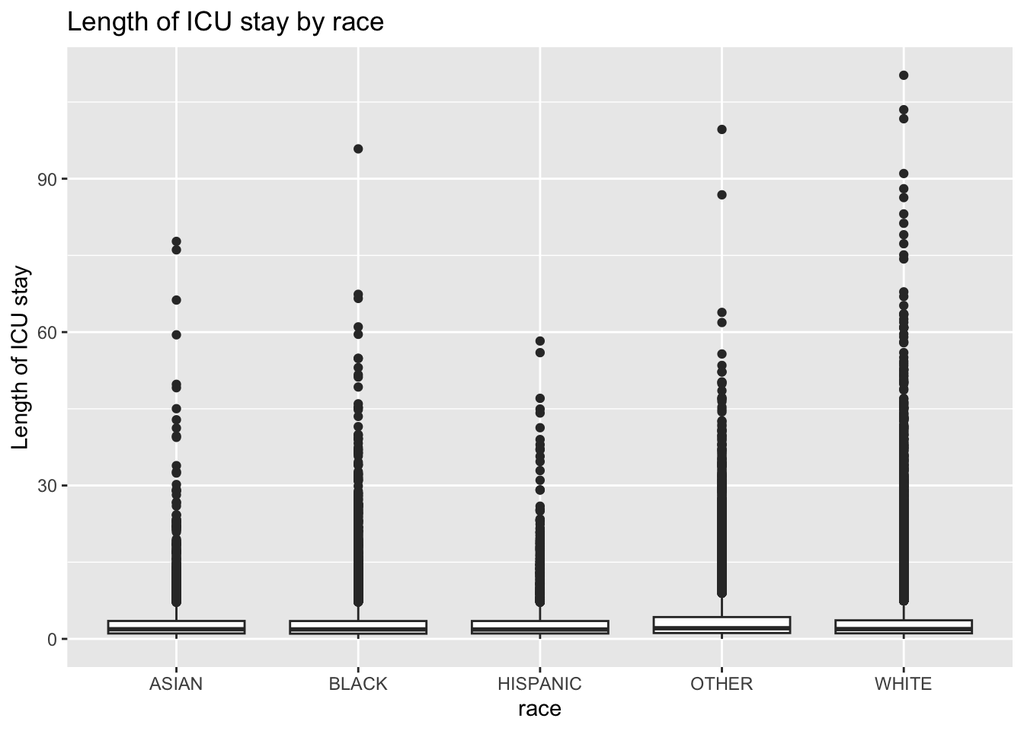

```r
race_los <- mimic_icu_cohort |>
  mutate(race_type = if_else(
    str_detect(race, "ASIAN"), "ASIAN", if_else(
      str_detect(race, "WHITE"), "WHITE", if_else(
        str_detect(race, "BLACK"), "BLACK", if_else(
          str_detect(race, "HISPANIC"), "HISPANIC", "OTHER")))))

gg_race_los <- race_los |>
  ggplot(aes(x = race_type, y = los)) +
  geom_boxplot() +
  labs(title = "Length of ICU stay by race",
       x = "race",
       y = "Length of ICU stay")

gg_race_los
```

```r
race_los <- mimic_icu_cohort |>
  group_by(race) |>
  summarise(
    n = n(),
    mean_los = mean(los),
    median_los = median(los),
    max_los = max(los),
    min_los = min(los),
    sd_los = sd(los),
    iqr_los = IQR(los))
race_los
```

```
# A tibble: 33 × 8
   race                     n mean_los median_los max_los min_los sd_los iqr_los
   <chr>                <int>    <dbl>      <dbl>   <dbl>   <dbl>  <dbl>   <dbl>
 1 AMERICAN INDIAN/ALA…   140     4.46       2.09    49.9 0.0879    6.54    4.01
 2 ASIAN                  840     3.49       1.93    59.5 0.0631    4.90    2.70
 3 ASIAN - ASIAN INDIAN   179     4.20       1.95    66.3 0.160     7.61    2.81
 4 ASIAN - CHINESE        792     3.36       1.86    77.7 0.0206    5.39    2.28
 5 ASIAN - KOREAN          51     4.23       2.08    39.4 0.211     6.35    2.85
 6 ASIAN - SOUTH EAST …   293     3.04       1.82    76.1 0.0784    5.42    1.90
 7 BLACK/AFRICAN          309     3.82       2.02    54.8 0.0345    5.90    3.04
 8 BLACK/AFRICAN AMERI…  6723     3.28       1.85    95.8 0.00346   4.80    2.43
 9 BLACK/CAPE VERDEAN     502     3.22       1.70    51.7 0.0296    4.94    2.53
10 BLACK/CARIBBEAN ISL…   426     3.61       1.95    38.2 0.0445    5.13    2.45
# ℹ 23 more rows
```

**los vs insurance**

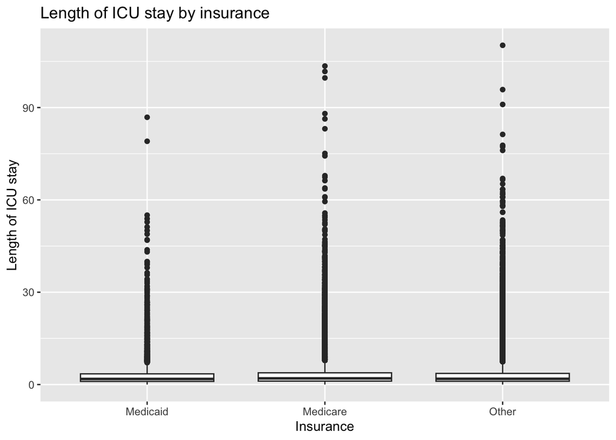

```r
insurance_los <- mimic_icu_cohort |>
  ggplot(aes(x = insurance, y = los)) +
  geom_boxplot() +
  labs(title = "Length of ICU stay by insurance",
       x = "Insurance",
       y = "Length of ICU stay")

insurance_los
```

```r
insurance_los <- mimic_icu_cohort |>
  group_by(insurance) |>
  summarise(
    n = n(),
    mean_los = mean(los),
    median_los = median(los),
    max_los = max(los),
    min_los = min(los),
    sd_los = sd(los),
    iqr_los = IQR(los))

insurance_los
```

```
# A tibble: 3 × 8
  insurance     n mean_los median_los max_los min_los sd_los iqr_los
  <chr>     <int>    <dbl>      <dbl>   <dbl>   <dbl>  <dbl>   <dbl>
1 Medicaid   5528     3.46       1.81    86.8 0.00625   5.18    2.46
2 Medicare  33091     3.48       2.01   103.  0.00145   4.79    2.71
3 Other     34562     3.42       1.87   110.  0.00125   5.00    2.55
```

**los vs marital status**

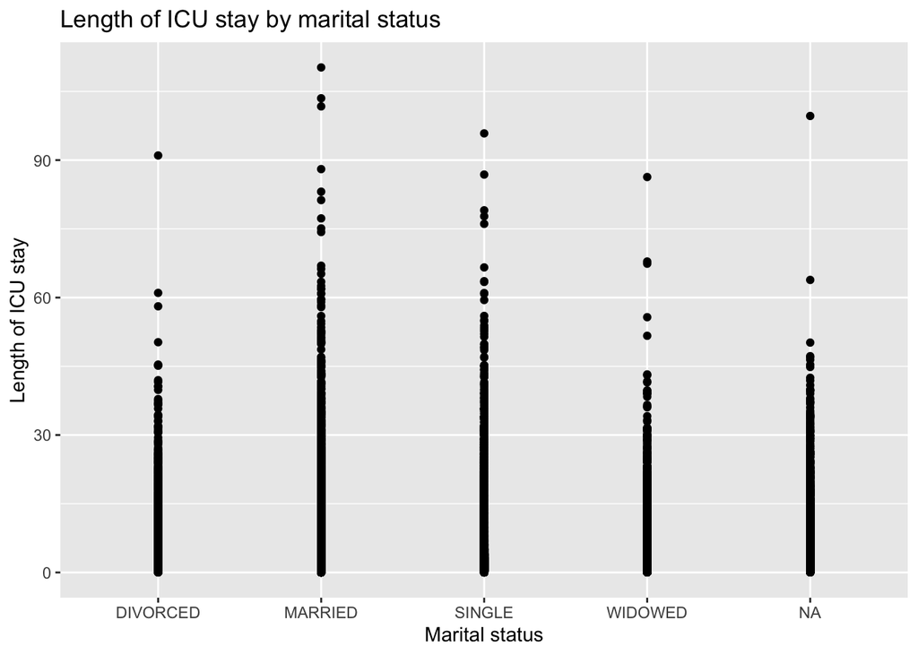

```r
marital_status_los <- mimic_icu_cohort |>
  ggplot(aes(x = marital_status, y = los)) +
  geom_point() +
  labs(title = "Length of ICU stay by marital status",
       x = "Marital status",
       y = "Length of ICU stay")

marital_status_los
```

```r
marital_status_los <- mimic_icu_cohort |>
  group_by(marital_status) |>
  summarise(
    n = n(),
    mean_los = mean(los),
    median_los = median(los),
    max_los = max(los),
    min_los = min(los),
    sd_los = sd(los),
    iqr_los = IQR(los))

marital_status_los
```

```
# A tibble: 5 × 8
  marital_status     n mean_los median_los max_los min_los sd_los iqr_los
  <chr>          <int>    <dbl>      <dbl>   <dbl>   <dbl>  <dbl>   <dbl>
1 DIVORCED        5404     3.39       1.90    91.0 0.0075    4.74    2.65
2 MARRIED        32768     3.46       1.94   110.  0.00125   5.00    2.56
3 SINGLE         20858     3.40       1.87    95.8 0.00227   4.92    2.59
4 WIDOWED         9038     3.13       1.93    86.3 0.00733   4.10    2.41
5 <NA>            5113     4.28       2.20    99.6 0.0203    5.78    3.70
```

**los vs gender**

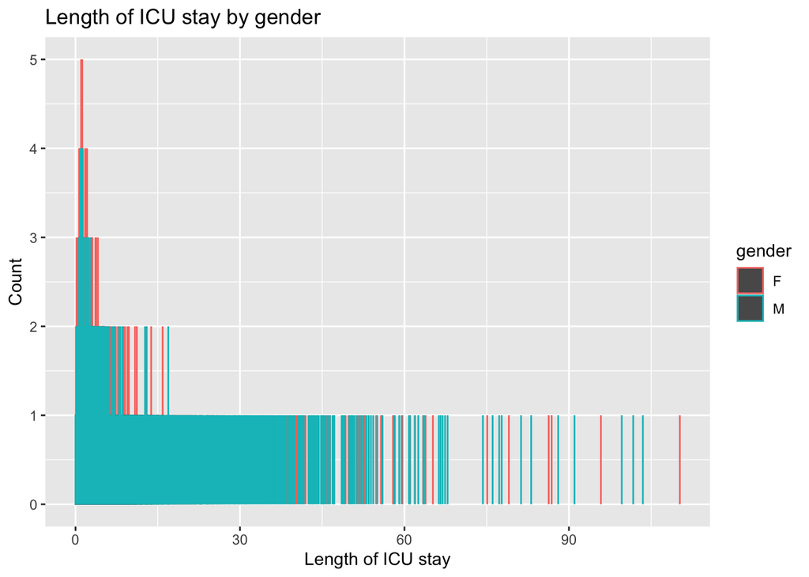

```r
gender_los <- mimic_icu_cohort |>
  ggplot(aes(x = los, color = gender)) +
  geom_bar() +
  labs(title = "Length of ICU stay by gender",
       x = "Length of ICU stay",
       y = "Count")

gender_los
```

```r
gender_los <- mimic_icu_cohort |>
  group_by(gender) |>
  summarise(
    n = n(),
    mean_los = mean(los),
    median_los = median(los),
    max_los = max(los),
    min_los = min(los),
    sd_los = sd(los),
    iqr_los = IQR(los))

gender_los
```

```
# A tibble: 2 × 8
  gender     n mean_los median_los max_los min_los sd_los iqr_los
  <chr>  <int>    <dbl>      <dbl>   <dbl>   <dbl>  <dbl>   <dbl>
1 F      32363     3.34       1.91    110. 0.00145   4.70    2.60
2 M      40818     3.54       1.94    103. 0.00125   5.09    2.65
```

**los vs age at intime**

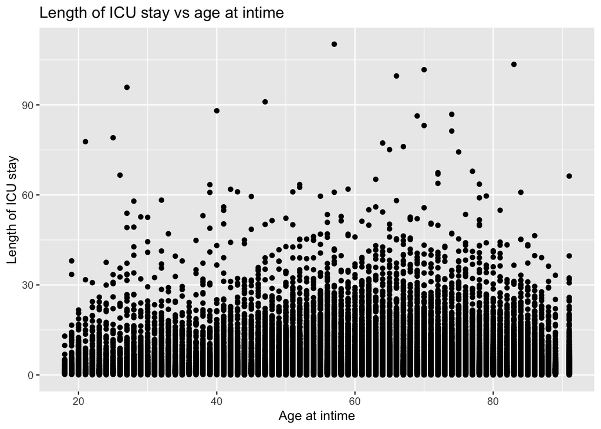

```r
age_at_intime_los <- mimic_icu_cohort |>
  ggplot(aes(x = age_at_intime, y = los)) +
  geom_point() +
  labs(title = "Length of ICU stay vs age at intime",
       x = "Age at intime",
       y = "Length of ICU stay")

age_at_intime_los
```

```r
age_at_intime_los <- mimic_icu_cohort |>
  group_by(age_at_intime) |>
  summarise(
    n = n(),
    mean_los = mean(los),
    median_los = median(los),
    max_los = max(los),
    min_los = min(los),
    sd_los = sd(los),
    iqr_los = IQR(los))

age_at_intime_los
```

```
# A tibble: 73 × 8
   age_at_intime     n mean_los median_los max_los min_los sd_los iqr_los
           <dbl> <int>    <dbl>      <dbl>   <dbl>   <dbl>  <dbl>   <dbl>
 1            18    99     1.85       1.16    12.9  0.202    1.93    1.39
 2            19   168     2.93       1.61    38.0  0.184    4.63    2.17
 3            20   357     2.53       1.42    21.6  0.0793   3.18    1.86
 4            21   259     2.85       1.63    77.7  0.104    5.78    1.77
 5            22   272     2.88       1.43    30.8  0.0784   4.17    1.87
 6            23   332     3.02       1.56    25.9  0.0345   4.09    2.23
 7            24   317     2.93       1.67    37.5  0.0838   4.26    2.07
 8            25   316     3.21       1.66    79.0  0.171    6.02    1.98
 9            26   300     2.96       1.54    66.6  0.0732   5.59    1.81
10            27   305     4.58       2.05    95.8  0.0256   8.62    3.00
# ℹ 63 more rows
```

- Length of ICU stay `los` vs the last available lab measurements before ICU stay

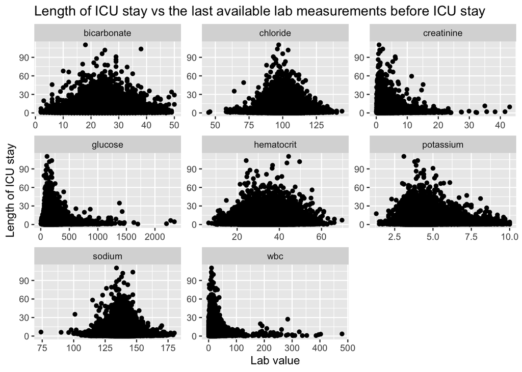

```r
lab_los <- mimic_icu_cohort |>
  select(los, creatinine, potassium, sodium, chloride, bicarbonate, hematocrit, wbc, glucose) |>
  pivot_longer(cols = -los, names_to = "lab", values_to = "value") |>
  ggplot(aes(x = value, y = los)) +
  geom_point() +
  facet_wrap(~lab, scales = "free") +
  labs(title = "Length of ICU stay vs the last available lab measurements before ICU stay",
       x = "Lab value",
       y = "Length of ICU stay")

lab_los
```

- Length of ICU stay `los` vs the average vital measurements within the first hour of ICU stay

```r
vital_los <- mimic_icu_cohort |>
  select(los, heart_rate, non_invasive_blood_pressure_systolic,
         non_invasive_blood_pressure_diastolic, temperature_fahrenheit,
         respiratory_rate) |>
  pivot_longer(cols = -los, names_to = "vital", values_to = "value") |>
  group_by(vital) |>
  summarise(
    mean_value = mean(value, na.rm = TRUE),
    median_value = median(value, na.rm = TRUE),
    max_value = max(value, na.rm = TRUE),
    min_value = min(value, na.rm = TRUE),
    sd_value = sd(value, na.rm = TRUE),
    iqr_value = IQR(value, na.rm = TRUE))

vital_los
```

```
# A tibble: 5 × 7
  vital           mean_value median_value max_value min_value sd_value iqr_value
  <chr>                <dbl>        <dbl>     <dbl>     <dbl>    <dbl>     <dbl>
1 heart_rate            88.6         86        941          0    20.7      27
2 non_invasive_b…       71.4         67      82127          0   398.       22
3 non_invasive_b…      123.         121      12262          0    51.5      33
4 respiratory_ra…       19.1         18        180          0     6.32      7
5 temperature_fa…       98.1         98.2      999.         0     4.68      1.10
```

- Length of ICU stay `los` vs first ICU unit

```r
unit_los <- mimic_icu_cohort |>
  group_by(first_careunit) |>
  summarise(
    n = n(),
    mean_los = mean(los),
    median_los = median(los),
    max_los = max(los),
    min_los = min(los),
    sd_los = sd(los),
    iqr_los = IQR(los))

unit_los
```

```
# A tibble: 9 × 8
  first_careunit            n mean_los median_los max_los min_los sd_los iqr_los
  <chr>                 <int>    <dbl>      <dbl>   <dbl>   <dbl>  <dbl>   <dbl>
1 Cardiac Vascular Int… 11582     3.29       1.99   103.  0.00352   4.89    2.08
2 Coronary Care Unit (…  8311     3.19       2.01    66.6 0.00125   4.00    2.64
3 Medical Intensive Ca… 15898     3.26       1.83   110.  0.00227   4.61    2.54
4 Medical/Surgical Int… 12733     3.08       1.81    67.9 0.00145   4.30    2.18
5 Neuro Intermediate     2035     3.42       2.34    43.5 0.00346   3.73    3.12
6 Neuro Stepdown         1007     2.59       1.69    29.1 0.0570    2.89    2.27
7 Neuro Surgical Inten…  1762     6.30       3.65    59.6 0.0216    7.46    5.95
8 Surgical Intensive C… 11161     3.84       1.97   102.  0.00745   5.76    2.95
9 Trauma SICU (TSICU)    8692     3.83       1.94    99.6 0.00218   5.52    2.95
```

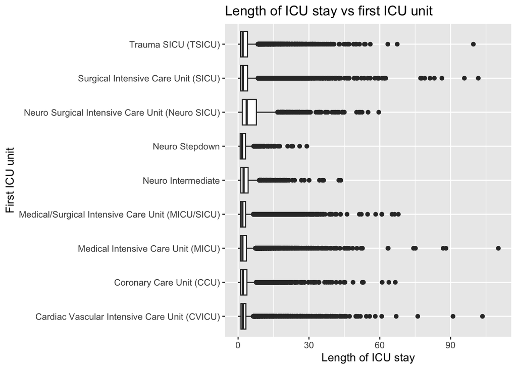

```r
unit_los <- mimic_icu_cohort |>
  ggplot(aes(x = los, y = first_careunit)) +
  geom_boxplot() +
  labs(title = "Length of ICU stay vs first ICU unit",
       x = "Length of ICU stay",
       y = "First ICU unit")

unit_los
```